# FigureYa171subgroupSurv

小丫画图出品

2020-3-29

欢迎关注“小丫画图”公众号，回复“小白”，看小视频，实现点鼠标跑代码。

小丫微信: epigenomics E-mail: figureya@126.com

作者：果子

小丫编辑校验

# 需求描述

我们对亚组进行分析（比如说，risk signature在不同的年龄、性别、gleason评分等）的时候，区分高危和低危之后，画图把高危和低危的预测放到不同的年龄或肿瘤级别中，看看是否仍然有效。 目前只能通过手动来做，是否可以帮忙做一个续惯的流程。 输入survival信息，和不同的临床亚组。

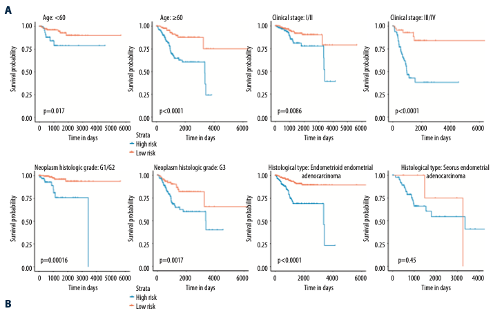

出自https://www.onlinelibrary.wiley.com/doi/full/10.1002/cam4.1498

Figure 7. Subgroup analyses revealed by Kaplan-Meier survival curve. (A) Stratified survival analyses based on the clinicopathological features age, clinical stage, histological stage, and neoplasm histological grade for the 7-miRNA-based OS classifier.

# 应用场景

本质上就是每次按条件筛选数据，然后做生存分析。

你可能还想看这篇： 8秒完成2万个基因的生存分析，人人都可以！ https://mp.weixin.qq.com/s/o4e1HzG4zPIQoGT6-7D0ug

# 环境设置

使用国内镜像安装包

```r
options("repos"= c(CRAN="https://mirrors.tuna.tsinghua.edu.cn/CRAN/"))
options(BioC_mirror="http://mirrors.ustc.edu.cn/bioc/")
```

加载包

```r
library(survival)
library(survminer)
Sys.setenv(LANGUAGE = "en") #显示英文报错信息
options(stringsAsFactors = FALSE) #禁止chr转成factor
```

# 输入文件

easy_input.csv，包含生存数据和临床亚组信息。

```r
dd <- data.table::fread("easy_input.csv",data.table = F)
dd[1:3,]
```

```
##             Id futime fustat Risk  age gleason  psa stage
## 1 TCGA.QU.A6IM   1247      0  Low  <60     <=7 <=10 T1+T2
## 2 TCGA.HC.7075    601      0  Low >=60     <=7 <=10 T1+T2
## 3 TCGA.G9.6347   2089      0  Low  <60     <=7 <=10 T1+T2
```

```r
## 自定义颜色
orange <- "#EB736B"
blue <- "#57B5AB"
```

# 以一个亚组为例

以age>=60为例，提取数据、绘制生存曲线。

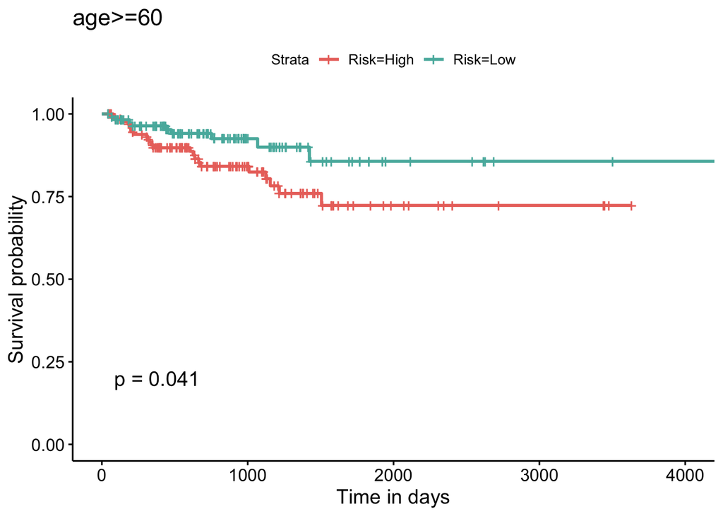

```r
## 提取数据
rt <- dd[dd$age==">=60",]

## 生存分析
fit <- survfit(Surv(futime, fustat) ~ Risk, data = rt)

## 作图
ggsurvplot(fit,
           pval = TRUE,
           palette = c(orange, blue),
           title="age>=60",
           xlab="Time in days")
```

# 批量操作

本质上就是每次按条件筛选数据，然后做生存分析，重点是在筛选数据

## 自定义函数

给一个筛选标准，直接画图。

支持单次操作

```r
mysurvplot <- function(cols=cols,filter=filter){
  ## 过滤条件
  index = dd[,cols]==filter
  ## 按行过滤数据
  rt = dd[index,]
  ## 生存分析
  fit = survfit(Surv(futime, fustat) ~ Risk, data = rt)
  ## 计算p值
  x = survdiff(Surv(futime, fustat) ~ Risk, data = rt)
  pValue=1-pchisq(x$chisq,df=1)
  pValue= round(pValue,3)
  ## 作图
  p=ggsurvplot(fit,
             pval = pValue,
             palette = c(orange, blue),
             title=paste0(cols,filter),
             xlab="Time in days")
  return(p)
}
```

## 函数用法

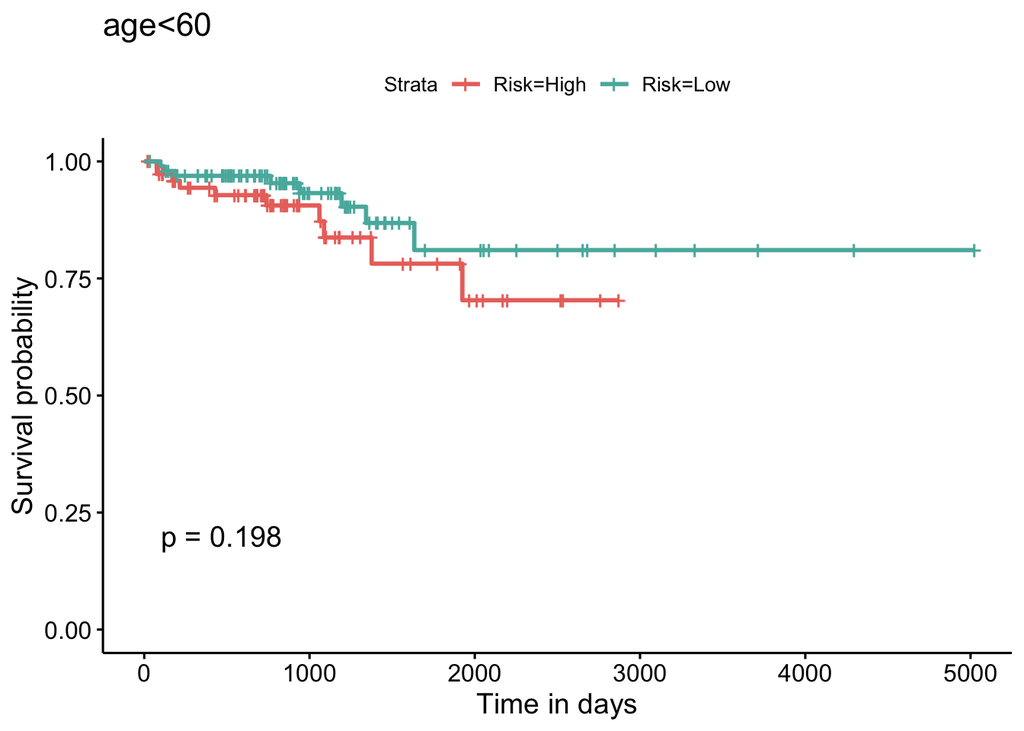

```r
# 举三个例子测试函数
mysurvplot("age","<60")
```

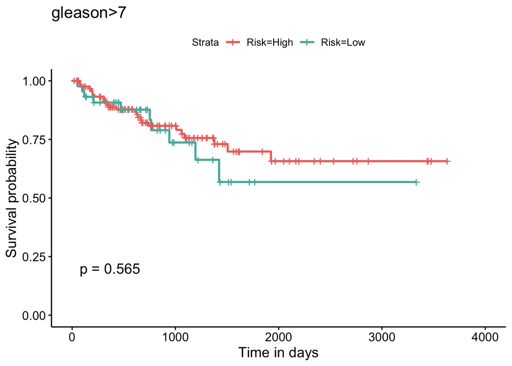

```r
mysurvplot("gleason",">7")
```

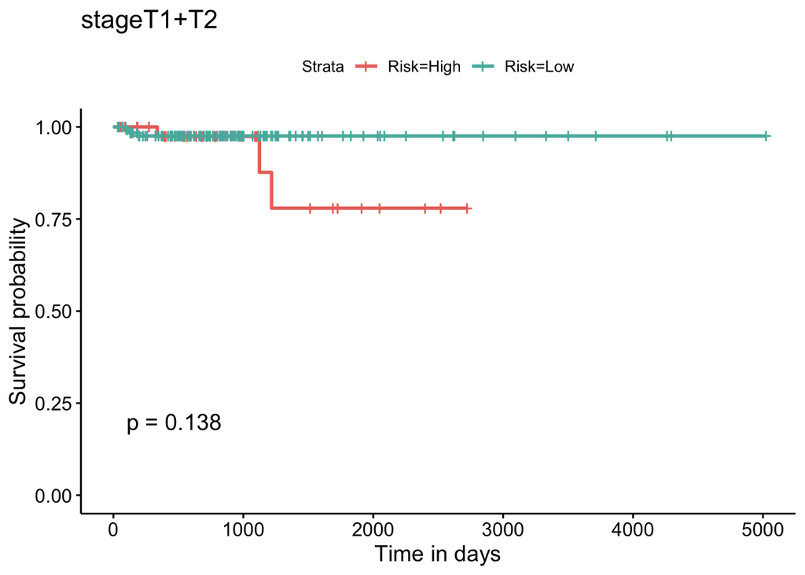

```r
mysurvplot("stage","T1+T2")
```

## 批量运行，把画图结果存为list

```r
# 为了方便批量操作，把筛选条件写成向量形式
cols <- c("age","age","gleason","gleason","psa","psa","stage","stage")
filter <- c(">=60","<60","<=7",">7","<=10",">10","T1+T2","T3+T4")

p <- list()
for ( i in 1:length(cols)) {
  p[[i]] = mysurvplot(cols[i],filter[i])
}
```

拼图

[figure not shown]

```r
## arrange_ggsurvplots来自于survminer包，用于排列结果
## print = T，直接显示
arrange_ggsurvplots(p, print = T,
                    ncol = 4, nrow = 2,
                    labels=LETTERS[1:8])
```

```r
## 或者print = F, 然后保存到PDF文件
res <- arrange_ggsurvplots(p, print = F,
                           ncol = 4, nrow = 2)
ggsave("subgroupSurv.pdf", res, width = 20, height = 10)
```